# Notes20251201

Blazej Kochanski

2025-12-15

Principal component analysis: https://en.wikipedia.org/wiki/Principal_component_analysis

We will use the data on fake and random series of coin tosses:

link: https://raw.githubusercontent.com/blakocha/ADRPY2025/refs/heads/main/cointosses.csv

```r
url = "https://raw.githubusercontent.com/blakocha/ADRPY2025/refs/heads/main/cointosses.csv"
coin <- read.csv(url)
head(coin)
```

```
##   X
## 1 1
## 2 2
## 3 3
## 4 4
## 5 5
## 6 6
##                                                                                                   toss
## 1 ORRROROOROOOORORROROORRRORORORORROROORRORRROORORROOOOORORRRRROORORROOOROORORRRORORROORRROOOORORORROR
## 2 OORORRRROORROROOROROROOOOORRRRORORROOORROORROROORRROROROROROOOORORRORRRRORROOOROOROOOORRRRROOOOORRRR
## 3 RROOROOOORORORORRROOORROOROROROOOORRORORORRRORROORROOROOORRRORORORROORRORROOORRRORROORRROOORROOORROO
## 4 OORRROOORRRORROOROOOORRROROROORORROOORRRRROOOORRORRRRROOROOROORRORORORROORRROOOROORORRROORRROOORORRR
## 5 OROROORROROOORRROORRORRROROOROORROORROOOOORORRRORRORORORRRORRORRRROORRROROROORROORORROROOOROOORROROR
## 6 ORROORORRORROOROROOROROROROORRRORORRORROROORROROOORRORORROROORORROROORROORORRORROORROORROROORORRRROR
##   fake pierwszy_O liczba_serii liczba_O max_seria   runtest_z       sd10
## 1    1          1           60       49         5  1.71336415 0.07378648
## 2    1          1           52       50         5  0.10050891 0.00000000
## 3    1          0           56       51         4  0.90896784 0.07378648
## 4    1          1           50       48         5 -0.08456417 0.06324555
## 5    1          1           60       48         5  1.72752513 0.09189366
## 6    1          1           68       47         4  3.36521561 0.06749486
##   sum_2max sum_3max sum_4max sum_5max sum_6max sum_7max count_1
## 1       10       14       18       21       24       27      36
## 2       10       15       19       23       27       31      28
## 3        8       11       14       17       20       23      26
## 4       10       14       18       21       24       27      21
## 5        9       12       15       18       21       24      33
## 6        7       10       12       14       16       18      40
```

The file cointains the data on 262 fake series of 100 coin tosses each generated by students on paper, as well as 262 random series of 100 coin tosses generated with the help of the (pseudo-)random number generator in R.

Variables:

- **toss** - a series of 100 coin toss results coded as O (“orzel”, *tails* in Polish) and R (“reszka”, *heads* in Polish),
- **fake** - an indicator variable, 1 if fake, 0 if randomly generated,
- **pierwszy_O** - pre-computed variable indicating whether the first toss in the series is “O”
- **liczba_serii** - number of runs (for example, in series: “OOORROOR” there are 4 runs: OOO, RR, OO, R)
- **liczba_O** - number of Os in the run
- **max_seria** - length of the longest run (for example, if the longest run is “OOOOO”, max_seria is 5)
- **runtest_z** - test statistic from the [Wald-Wolfowitz runs test](https://en.wikipedia.org/wiki/Wald%E2%80%93Wolfowitz_runs_test)
- **sd10** - standard deviation of number of Os in each row of ten tosses
- **sum_2max**, **sum_3max**, **sum_4max**, etc. - sum of lengths of the 2, 3, 4, etc. longest series
- **count_1** - number of runs of length 1

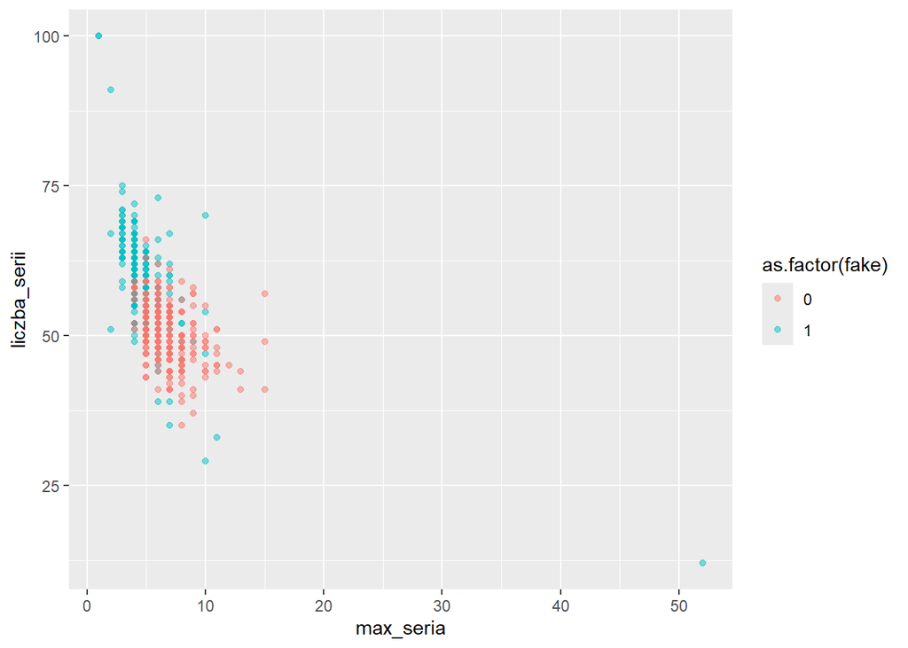

```r
library(ggplot2)

ggplot(coin, aes(x = max_seria, y = liczba_serii, col=as.factor(fake))) +
         geom_point(alpha = 0.5)
```

```r
library(plotly)

plot_ly(
  data = coin,
  x = ~max_seria,
  y = ~liczba_serii,
  z = ~liczba_O,
  color = ~as.factor(fake),
  type = "scatter3d",
  mode = "markers",
  marker = list(opacity = 0.5)
)
```

[interactive chart not shown]

```r
X <- coin[,4:16]
pca <- prcomp(X, scale. = TRUE)
summary(pca)
```

```
## Importance of components:
##                           PC1    PC2     PC3     PC4     PC5     PC6     PC7
## Standard deviation     3.0190 1.1498 1.02410 0.95360 0.62847 0.38873 0.17019
## Proportion of Variance 0.7011 0.1017 0.08068 0.06995 0.03038 0.01162 0.00223
## Cumulative Proportion  0.7011 0.8028 0.88350 0.95345 0.98383 0.99546 0.99769
##                            PC8     PC9    PC10    PC11    PC12    PC13
## Standard deviation     0.13256 0.07852 0.05187 0.04701 0.03187 0.02090
## Proportion of Variance 0.00135 0.00047 0.00021 0.00017 0.00008 0.00003
## Cumulative Proportion  0.99904 0.99951 0.99972 0.99989 0.99997 1.00000
```

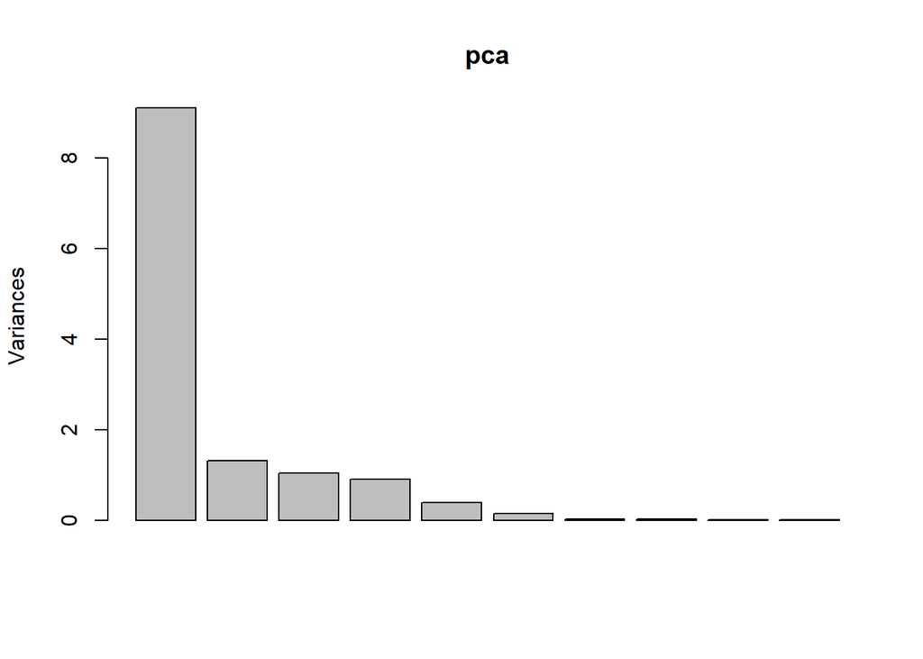

```r
plot(pca)
```

The values of principal components are stored in pca$x

```r
head(pca$x)
```

```
##             PC1        PC2         PC3        PC4       PC5        PC6
## [1,] -1.2443933  0.8662153 -0.24307084 -0.5617254 0.5385348  0.4889228
## [2,] -0.3113750 -0.3419979 -0.49770217 -0.8172408 2.1426048  1.2122173
## [3,] -1.9388753 -1.2931332  0.85325113  0.7342061 0.6215789 -0.2580834
## [4,] -0.2479643 -1.0179067 -0.16595681 -1.2863610 1.0839828  0.1396876
## [5,] -1.9010807  0.3760434 -0.04394127 -0.8542151 0.1295129 -0.1836676
## [6,] -4.0759724  1.0884595  0.25143735 -0.8366247 0.1099378 -0.3981673
##              PC7        PC8         PC9        PC10          PC11          PC12
## [1,] -0.08137642 0.09853546  0.00861223  0.03624201  0.0099602510 -0.0435320808
## [2,]  0.20771110 0.16258084 -0.02661282  0.03236387 -0.0790255229  0.0253424278
## [3,]  0.03731877 0.11123757 -0.03108714  0.04843533  0.0127269798 -0.0009556166
## [4,] -0.05579991 0.22864063  0.05806421 -0.02833447  0.0742560980 -0.0333451559
## [5,]  0.04532691 0.07235034 -0.06966604  0.02536900 -0.0008380513 -0.0084899819
## [6,] -0.17223369 0.06560360  0.03954091 -0.06075027 -0.0357108496  0.0172480750
##               PC13
## [1,] -0.0078356786
## [2,]  0.0086343352
## [3,]  0.0061091660
## [4,] -0.0133221512
## [5,]  0.0046664860
## [6,] -0.0002021111
```

```r
library(ggplot2)
x2 <- data.frame(pca$x, fake = coin$fake)
head(x2)
```

```
##          PC1        PC2         PC3        PC4       PC5        PC6         PC7
## 1 -1.2443933  0.8662153 -0.24307084 -0.5617254 0.5385348  0.4889228 -0.08137642
## 2 -0.3113750 -0.3419979 -0.49770217 -0.8172408 2.1426048  1.2122173  0.20771110
## 3 -1.9388753 -1.2931332  0.85325113  0.7342061 0.6215789 -0.2580834  0.03731877
## 4 -0.2479643 -1.0179067 -0.16595681 -1.2863610 1.0839828  0.1396876 -0.05579991
## 5 -1.9010807  0.3760434 -0.04394127 -0.8542151 0.1295129 -0.1836676  0.04532691
## 6 -4.0759724  1.0884595  0.25143735 -0.8366247 0.1099378 -0.3981673 -0.17223369
##          PC8         PC9        PC10          PC11          PC12          PC13
## 1 0.09853546  0.00861223  0.03624201  0.0099602510 -0.0435320808 -0.0078356786
## 2 0.16258084 -0.02661282  0.03236387 -0.0790255229  0.0253424278  0.0086343352
## 3 0.11123757 -0.03108714  0.04843533  0.0127269798 -0.0009556166  0.0061091660
## 4 0.22864063  0.05806421 -0.02833447  0.0742560980 -0.0333451559 -0.0133221512
## 5 0.07235034 -0.06966604  0.02536900 -0.0008380513 -0.0084899819  0.0046664860
## 6 0.06560360  0.03954091 -0.06075027 -0.0357108496  0.0172480750 -0.0002021111
##   fake
## 1    1
## 2    1
## 3    1
## 4    1
## 5    1
## 6    1
```

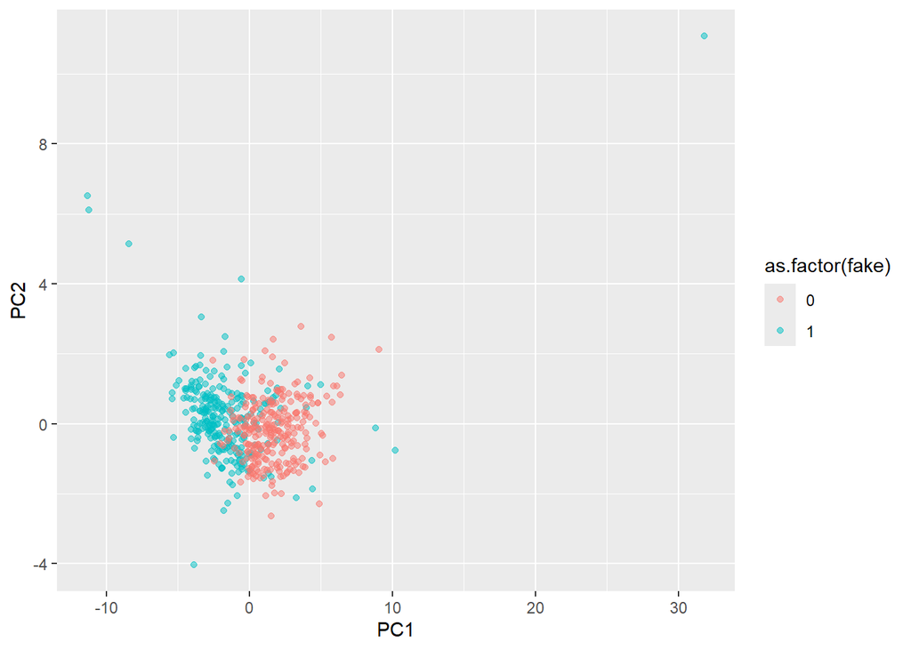

```r
ggplot(x2, aes(x = PC1, y = PC2, col=as.factor(fake))) +
         geom_point(alpha = 0.5)
```

```r
library(plotly)

plot_ly(
  data = x2,
  x = ~PC1,
  y = ~PC2,
  z = ~PC3,
  color = ~as.factor(fake),
  type = "scatter3d",
  mode = "markers",
  marker = list(opacity = 0.5)
)
```

[interactive chart not shown]

```r
pca$rotation
```

```
##                      PC1         PC2          PC3         PC4           PC5
## pierwszy_O   -0.03676900  0.19670942 -0.689472925 -0.69267674 -0.0623880662
## liczba_serii -0.29280782  0.39124484  0.020618366  0.09598115 -0.0308341790
## liczba_O     -0.03486822 -0.15970993 -0.722095085  0.66911483  0.0516075699
## max_seria     0.28896286  0.32832091 -0.001200467  0.02464728  0.2777324618
## runtest_z    -0.28859326  0.40936188  0.020995667  0.11022393 -0.0293701690
## sd10          0.26736618  0.01236857 -0.006678629  0.06690017 -0.9164031640
## sum_2max      0.31234754  0.24966865 -0.014530224  0.05432744  0.1559920698
## sum_3max      0.32062980  0.19153103 -0.019246023  0.05097012  0.1022714496
## sum_4max      0.32395487  0.15500628 -0.015289085  0.04330422  0.0682784009
## sum_5max      0.32561087  0.12493784 -0.010899017  0.03196909  0.0417493130
## sum_6max      0.32652068  0.07964077 -0.014972163  0.02896805 -0.0005841653
## sum_7max      0.32594811  0.04027769 -0.018067231  0.02382907 -0.0315437139
## count_1      -0.22188729  0.60048392  0.028445079  0.19022562 -0.1802988842
##                       PC6          PC7         PC8           PC9          PC10
## pierwszy_O    0.026960031 -0.001177179  0.01111765 -0.0003790186 -0.0035727550
## liczba_serii -0.069189382 -0.325629530 -0.31884282 -0.0272867173  0.6468663395
## liczba_O     -0.031095050  0.015135830 -0.01430829  0.0066578745  0.0053021677
## max_seria    -0.613448281  0.497790359 -0.25862786  0.1514682482 -0.0552920463
## runtest_z    -0.069352459 -0.318761847 -0.36645469 -0.2049483119 -0.6288366318
## sd10         -0.286209391 -0.029506378 -0.03154224  0.0158564208 -0.0006624020
## sum_2max     -0.239690637 -0.223167849  0.43408945 -0.5609160733  0.2343322884
## sum_3max      0.003139961 -0.395411865  0.32407083  0.1587003118 -0.2750621820
## sum_4max      0.160452363 -0.278019613  0.01583748  0.4475979184 -0.0479779629
## sum_5max      0.236924521 -0.083827551 -0.26112228  0.3314978098  0.1806184274
## sum_6max      0.329230104  0.056117437 -0.31660197 -0.1707837031  0.0871067414
## sum_7max      0.396554980  0.221362852 -0.24465059 -0.4878273386 -0.0997321602
## count_1       0.354241086  0.448143808  0.41696123  0.1297042290  0.0002964594
##                       PC11         PC12          PC13
## pierwszy_O    0.0047082030  0.000344769 -0.0004168306
## liczba_serii -0.3420843405 -0.043656645 -0.0034759561
## liczba_O      0.0013651178  0.000631307  0.0014861439
## max_seria    -0.1139604876 -0.008713823 -0.0299404010
## runtest_z     0.2374669682 -0.011590623  0.0318103436
## sd10         -0.0004234985 -0.003644188  0.0008192568
## sum_2max      0.3732200669 -0.085005610  0.0293543451
## sum_3max     -0.5626490568  0.401547827  0.0839206051
## sum_4max      0.0845442188 -0.667356501 -0.3252790274
## sum_5max      0.4212375413  0.248683593  0.6019474540
## sum_6max      0.1226658551  0.441003785 -0.6541510490
## sum_7max     -0.3947770616 -0.355706776  0.3063278513
## count_1       0.0471670351  0.034402573 -0.0165729483
```